# Projet BIO401-Partie_2

AmigoTeam

2024-04-09

# Un modèle pour déterminer l’effet des différentes intensités des ouragans sur le long terme des récifs coralliens.

Par Antoince Castonguay et Félix Richard. L’AmigoTeam.  
antoine.castonguay@usherbrooke.ca  
felix.richard3@usherbrooke.ca

## Résumé

Cette étude vise à améliorer la représentation des impacts des ouragans sur les récifs coralliens, en enrichissant le modèle de Blackwood, Hastings, and Mumby (2011). Nous avons introduit une composante plus réaliste de l’impact des ouragans, ainsi qu’une augmentation de l’intensité des ouragans au fil des années, reflétant ainsi les changements climatiques actuels. Nos simulations montrent que les ouragans de forte intensité ont un impact important sur la stabilité des populations de coraux, lorsque l’effort de pêche est élevé tandis que pour un effort de pêche faible ou moyenne, l’impact est faible.

## Introduction

Pour lutter contre la dégradation des récifs coralliens, il est crucial d’agir pour préserver cette ressource inestimable qui favorise la biodiversité des océans. Le modèle développé par Blackwood, Hastings, and Mumby (2011) est particulièrement intéressant, car il décrit bien les effets de plusieurs stress et leurs interactions sur la survie des coraux à long terme.

Ils abordent premièrement la compétition de l’espace entre les macroalgues et les coraux. Deuxièmement, ils ajoutent au modèle la relation consommateur-ressource entre les poissons-perroquets et les macroalgues. En troisième lieu, la rugosité des coraux est également considérée comme un élément crucial pour la capacité de soutien des populations de poisson-perroquets, tandis que l’effort de pêche joue un rôle important sur la population de poisson-perroquets. Enfin, le modèle inclut un élément stochastique représenté par les ouragans, qui ont un impact sur les populations de coraux, de macroalgues et sur la rugosité des coraux.

Dans notre étude, nous avons cherché à rendre ce modèle plus réaliste en y ajoutant une composante plus variable et aléatoire simulant de manière plus précise l’impact réel des ouragans. De plus, nous avons intégré une augmentation de l’intensité des ouragans au fil des années, ce qui reflète la situation actuelle avec les changements climatiques (Hernández-Delgado et al. (2024)).

## Méthode

Dans ce modèle, nous avons concentré nos efforts sur F() et G() ainsi qu’un nouveau paramètre i qui caractérise la farce de l’impact.

Notre objectif est d’améliorer ce modèle :

Modèle avec implémentation d’ouragans stochastique :  
$\small{dC = g_C(C,M,P,R,t)dt - C(F() + \sigma \epsilon)dq}$  
$\small{dM = g_M(C,M,P,R,t)dt - Mm_Hdq}$  
$\small{dP = g_P(C,M,P,R,t)dt}$  
$\small{dR = g_R(C,M,P,R,t)dt - (R-1)(G() + \sigma \epsilon)dq}$  
$\small{dY = 1 - M - C}$

$\small{F() = 0.0512 + 0.0176*te}$ avec un maximum de F() = 0.5. $\small{G() =}$ soit 0.5 pour un impact élever, soit F() pour un impact moyen et soit 0.05 pour un impact faible.

$\small{K(M+T,R) = }\frac{(c1R + c2)}{K_{max}}\frac{\delta(M+Y)}{1 + v(M+Y)}$

#### Tableau 1 : Paramètre utilisés dans le modèle et leurs définitions.

[output not shown]

#### Tableau 2 : Variables utilisées dans le modèle et leur définition ainsi que leurs limites.

[output not shown]

Afin d’ajouter au modèle stochastique de l’article de Blackwood, Hastings, and Mumby (2011), nous avons modifié légèrement le modèle pour tenter de remplacer les catégories d’impact par un coefficient d’impact continu. Cette démarche a pour but de pouvoir plus facilement visualiser la gradation de l’effet de la puissance des ouragans sur la résilience du corail dans diverses situations. Dans un contexte de changements climatiques, nous nous attendons à percevoir des différences au niveau de l’ampleur des phénomènes météorologiques tels que les ouragans. Nous nous sommes basés sur le document de Cervantes et al. (2020) sur les relations entre les caractéristiques des ouragans, la structure du récif de corail et l’impact de ces perturbations sur la rugosité et le couvert.

Avant tout, nous nous sommes débarrassés des 3 niveaux d’impacts qui étaient implémentés dans le modèle proposé par Blackwood, Hastings, and Mumby (2011). Dans leur cas, un ouragan avec impact qualifié de fort ou modéré a pour effet de réduire d’un pourcentage $F+\sigma\epsilon$ le couvert de corail, où $F$ est une fonction du temps écoulé depuis le dernier ouragan $t_e$, de sorte que l’impact soit en moyenne linéairement plus grand plus le dernier ouragan date, jusqu’à concurrence de 50% de réduction, qui est atteinte quand le dernier ouragan s’est passé il y a 25.5 années ou plus. La composante $\sigma$ est une variance fixée à 0,05 et $\epsilon$ est tiré aléatoirement d’une distribution normale, le tout pour conférer une certaine variabilité à l’effet sur le couvert de corail. Les ouragans de faible puissance sont ici considérés comme ne réduisant pas significativement le couvert de corail. L’effet sur la rugosité est fixé à 50% de réduction, sur une échelle allant de 3 à 1 (50% d’une rugosité de 3 résulte en une rugosité de 2), dans le cas d’un ouragan à impact fort, à 5% de réduction pour un ouragan à faible intensité tandis que dans le cas d’un ouragan d’intensité modéré, la réduction de la rugosité est calculée de la même façon que celle du couvert de corail. Le dommage causé aux macroalgues est considéré par ce modèle comme constant, peu importe l’intensité des ouragans, avec une perte ($m_H$) de 80% du couvert M lors d’un évènement d’ouragan.

On obtient ainsi les équations suivantes pour déterminer le dommage à chaque composante, dans le cas où un ouragan survient:

Ouragan à fort impact:

- $dC=C\times (F+\sigma \epsilon)$
- $dM=M\times m_H$
- $dR=(R-1)\times 0.5$

Ouragan à impact modéré:

- $dC=C\times (F+\sigma \epsilon)$
- $dM=M\times m_H$
- $dR=(R-1)\times (F+\sigma \epsilon)$

Ouragan à impact faible:

- $dC=0$
- $dM=M\times m_H$
- $dR=(R-1)\times 0.05$

Pour le modèle que nous proposons, la première modification apportée est que nous fixons un coefficient d’impact $i$ pour la simulation qui agit sur le dommage subi par chaque composante. Ainsi ce coefficient d’impact d’une valeur variant entre 0 et 1 dicte le dommage subi par les différents éléments de la simulation. Nous ajustons l’étendue possible de $dC$, $dM$ et $dR$ afin que la variabilité des dommages entre un coefficient d’impact à 1 et un coefficient d’impact à 0 corresponde aux limites de ce qui est observé par le document de Pérez-Cervantes et al. (2020). Ainsi, la perte de couvert de corail est également proportionnelle à $F$, mais est bornée à 0% quand $i\in [0,0.3]$, correspondant à un ouragan de trop faible intensité pour réduire le couvert coralliens, et varie linéairement entre 0% et 75% quand $i\in[0.3,1]$. Pour le couvert de macroalgues, le dommage subi reste en moyenne le même, soit 80%, mais le coefficient d’impact ajoute une variabilité de 25% qui fait en sorte que le dommage varie proportionnellement entre 60% et 100% selon la valeur de $I$. Cette modification pallie partiellement le fait qu’en situation d’ouragan plutôt faible, les macroalgues sont désavantagées par rapport au corail. Pour la rugosité, la littérature semblait démontrer que la proportion de rugosité perdue était proportionnelle à la valeur de rugosité elle-même, nous avons donc ajouté la composante $G=0.1\times (R-1)$ ainsi qu’une relation avec $i$ faisant ainsi varier $dR$ entre 0 et 50% selon $R$ et $i$, mais seulement limité entre 0% et 5% si $i=0$.

Tout comme dans le modèle de Blackwood, Hastings, and Mumby (2011), l’évènement d’un ouragan est déterminé par un tirage aléatoire dans une distribution de poisson à moyenne $\lambda$, ce tirage offre donc une probabilité $\lambda \times dt$ qu’un ouragan arrive (si le résultat du tirage est >0) pour chaque pas de temps.

Les équations différentielles qui déterminent la dynamique des composantes du modèle (C, M, Y, P et R) restent sinon inchangées dans tous les cas où un ouragan n’a pas lieu. Le modèle est sous forme de fonction et est construit avec le logiciel R. Les arguments de cette fonction sont la rugosité initiale du système, entre 1 et 3, l’effort de pêche relatif au taux de croissance de la population de poissons-perroquets, entre 0 et 1, la fréquence moyenne estimée des ouragans, entre 0 et 1, le coefficient d’impact, entre 0 et 1 et la taille des pas de temps (dt). Ce dernier argument permet d’ajuster le nombre d’étapes effectuées par la fonction, où plus dt est grand, plus la simulation s’effectue en temps discret et plus dt est petit, plus on se rapproche d’une simulation en temps continu. Cet argument dicte indirectement aussi le temps nécessaire pour calculer la simulation. L’argument facultatif “graph” peut être fixé à TRUE pour faire s’afficher un graphique de la simulation.

```r
corailstochastiquev2 <- function (R0,f,lambda=1/30,impact=0.5,dt=1,graph=FALSE){
  #on instaure une étendue de temps
  tmax <- 100
  t <- 0
  #le temps au dernier ouragan, en tenant compte que la simulation ne commence pas nécessairement juste après un ouragan
  to <- runif(1,0,25.5)

  #on pose les valeurs de départ et les paramètres
  C <- 0.56
  M <- 0.01
  Y <- 0.43
  R <- R0
  P <- 0.5
  a<-0.1
  g<-0.8
  d<-0.44
  r<-1
  f<-f
  s<-0.49
  ca<--(3.21)
  cb<-3.65
  kmax<-17.745
  delta<-4.557
  v<-0.9877
  hG<-0.03
  hE<-0.01
  o <- 0.05
  mH <- 0.8

  #on initie les vecteurs de résultats
  vecC <- C
  vecM <- M
  vecY <- Y
  vecR <- R
  vecP <- P

  while (t<tmax){

    #on effectue le tirage pour déterminer si il y a ou pas ouragan
    ouragan <- pmin(rpois(1,lambda*dt),1)
    #si oui ou non, on ajuste dq
    if (ouragan==1){

      #on calcule le temps depuis le dernier ouragan
      te <- t - to

      #on sauve le nouveau temps de dernier ouragan
      to <- t

      #on calcule F
      F <- pmin(0.0512 + 0.0176*(t/200+1)*te, 0.5)
      G <- (R-1)*0.1

      #différents dommage selon valeur d'impact

      #on calcule les dommages d'un fort ouragan
      dommM <- M*mH*(0.75+impact*0.5)
      dommC <- C*(F + o*runif(1))*pmax(2*impact-0.6,0)
      dommR <- (R-1)*(G + o*runif(1))*(impact*2.25+0.25)

    }else{
      dommC <- 0
      dommM <- 0
      dommR <- 0
    }

    #on calcule les changements
    dC <- ((r)*Y*C - (d)*C - (a)*M*C)*dt - dommC
    dM <- ((a)*M*C - ((1)*P*M/(M+Y)) + (g)*M*Y)*dt - dommM
    dP <- ((s)*P*(1 - (P/((((ca+cb*R)/kmax)*((delta*(M+Y))/(1+v*(M+Y))))))) -(f*s)*P)*dt
    dR <- ((hG)*C*(3 - R) - (hE)*(1 - C)*(R - 1))*dt - dommR

    #on effectue les changements
    C <- pmax(C + dC,0.0001)
    M <- pmax(M + dM,0.0001)
    P <- pmax(P + dP, 0.0001)
    R <- R + dR
    Y <- 1 - M - C

    #on sauve les nouvelles valeurs dans leur vecteurs
    vecC <- c(vecC,C)
    vecM <- c(vecM,M)
    vecY <- c(vecY,Y)
    vecR <- c(vecR,R)
    vecP <- c(vecP,P)

    #on fait avancer le temps
    t <- t + dt
  }
  #si on veut afficher le graphique
  if (graph==TRUE){
    par(mfrow=c(1,1))
    plot(seq(0,tmax,length.out = length(vecC)),vecC, type="l", col="red", ylim=c(0,1), xlab= "temps", ylab="valeurs")
    axis(side = 4,at= seq(0,1,0.1),labels = seq(1,3,0.2), )
    lines(seq(0,tmax,length.out = length(vecM)),vecM, col="blue")
    lines(seq(0,tmax,length.out = length(vecP)),vecP, col="green")
    lines(seq(0,tmax,length.out = length(vecR)),(vecR-1)/2, col="pink")
    legend("topright", legend = c("corail", "macroalgues","poissons","rugosité"),
           col = c("red","blue","green","pink"), lty = c(1, 1),
           lwd = 2, bg = "white",cex = 0.75)
  }
  #retourne la valeur finale de C et de R
  return(c(tail(vecC,1),tail(vecR,1)))
}
```

## Résultats

Pour mieux comprendre comment répond la résilience du corail face à différentes combinaisons de force d’impact et de rugosité initiale, pour différents efforts de pêche, nous effectuons 10 simulations de 100 ans par combinaison de R et i, et ce pour les 3 différentes valeurs d’effort de pêche correspondant à un effort minime, modéré et élevé avec les valeurs suivantes: 0.1, 0.4 et 0.7. Ces valeurs sont tirées de nos propres observations dans les figures présentées par Blackwood, Hastings, and Mumby (2011). Au bout de 100 ans, avec la paramétrisation utilisée, quand l’effort de pêche était aux alentours de 0.1, le corail se rétablissait très souvent. Quand l’effort de pêche était plus grand que 0.6, le corail finissait très souvent par s’effondrer au profit des macroalgues. La situation intermédiaire avec un effort de pêche à mi-chemin produisait différentes situations dépendamment de plusieurs facteurs. Nous avons donc considéré plus ou moins arbitrairement que 0.1, 0.4 et 0.7 représentaient respectivement un effort de pêche faible, moyen et fort. Les images générées ensuite représentent ainsi la moyenne et l’écart-type du résultat des 10 simulations. Nous faisons cela 2 fois, une fois avec le résultat en termes de couverture par le corail et une autre avec le résultat pour la rugosité après 100 ans. Pour toutes ces simulations, la fréquence moyenne estimée des ouragans est fixée à 1/15, correspondant à une fréquence intermédiaire d’un ouragan aux 15 ans, et le pas de temps est ajusté à 0.1 pour conférer une bonne résolution aux résultats tout en optimisant le temps nécessaire pour calculer chaque simulation.

```r
library(fields)
```

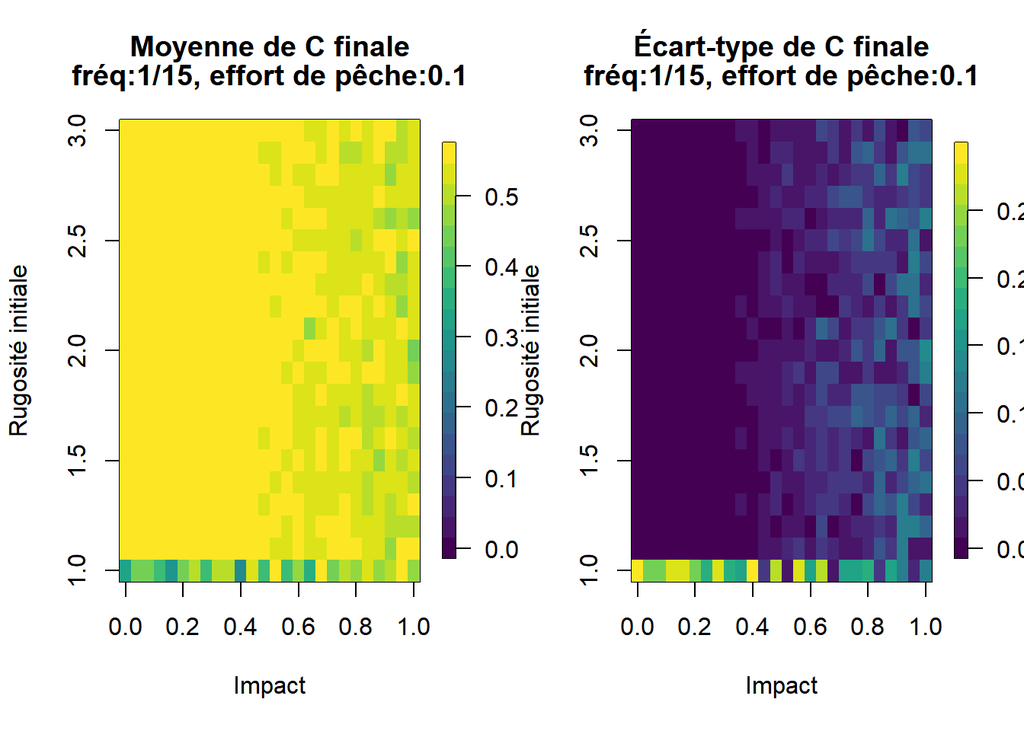

```r
#graphique de C en fonction de I et R
graph.imageCIR <- function(fishing,freq,it=10,pas=0.1){

  matC <- matrix(0, nrow = 21,ncol = 26)
  matsd <- matrix(0, nrow = 21,ncol = 26)


  f0<-fishing
  l<-freq
  for (i in 1:21) {
    for (j in 1:26){
      res <- vector(length = 0)
      for (z in 1:it) {
        R1 <- i*0.1+0.9
        imp <- j*0.04-0.04
        w <- corailstochastiquev2(R0=R1,f=f0, lambda = l,impact = imp,dt=pas, graph = F)[1]
        res<-c(res,w)
      }
      matC[i,j]<-mean(res)
      matsd[i,j]<-sd(res)
    }
  }

  x_values <- seq(0, 1, length.out = ncol(matC))
  y_values <- seq(1, 3, length.out = nrow(matC))
  # Plot the matrix as an image with different colored pixels

  par(mfrow=c(1,2))
  image.plot(x = x_values, y = y_values, t(matC), col = viridis(20), zlim = c(0,0.56),
             xlab = "Impact", ylab = "Rugosité initiale",
             main=c("Moyenne de C finale",paste(c("fréq:1/",1/l,", effort de pêche:",f0),collapse = "")))
  image.plot(x = x_values, y = y_values, t(matsd), col = viridis(20),
             xlab = "Impact", ylab = "Rugosité initiale",
             main=c("Écart-type de C finale",paste(c("fréq:1/",1/l,", effort de pêche:",f0),collapse = "")))
}
graph.imageCIR(fishing = 0.1, freq = 1/15, it=10, pas = 0.1)
```

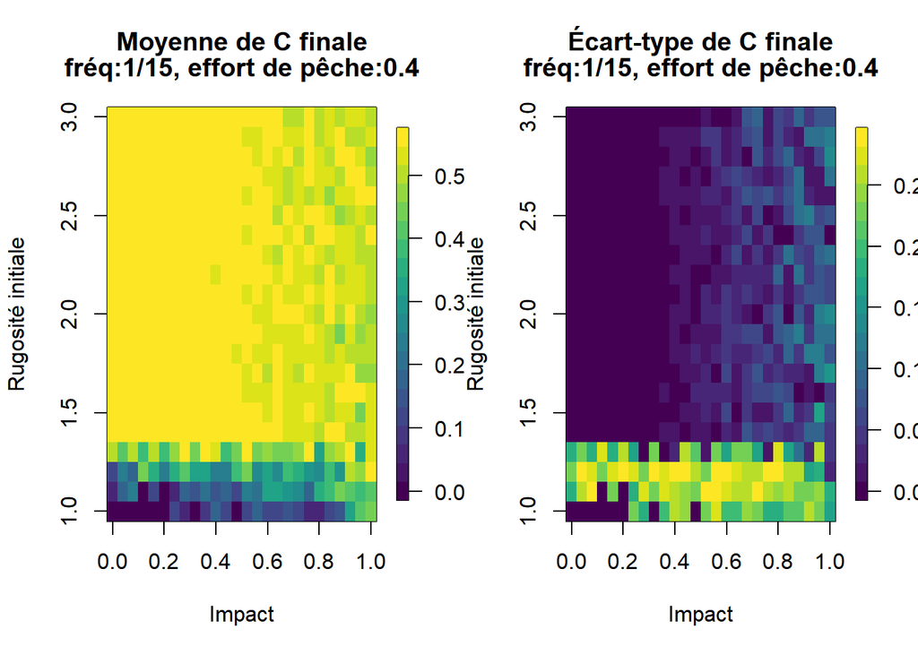

```r
graph.imageCIR(fishing = 0.4, freq = 1/15, it=10, pas = 0.1)
```

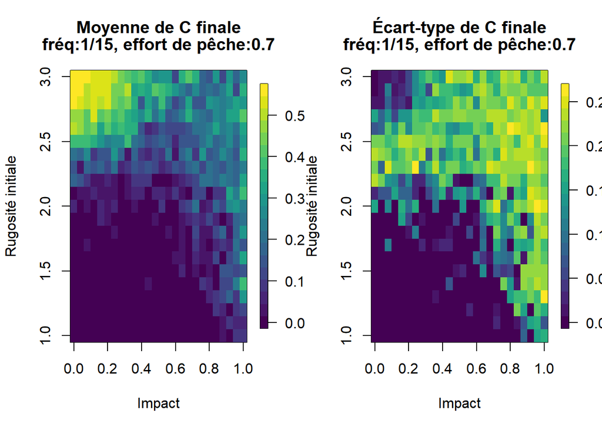

```r
graph.imageCIR(fishing = 0.7, freq = 1/15, it=10, pas = 0.1)
```

Un premier élément à noter est qu’une tendance générale peut être observée dans le graphique présentant l’état du corail, indiquant que plus l’impact est élevé, plus la situation des coraux est instable. Cette observation s’observe aussi dans les graphiques qui représentent les écarts-types. D’ailleurs, on peut noter que l’étendue des écarts-types est large. Pour une même simulation, les écarts maximum peuvent aller jusqu’à 30%. D’autre part, il est intéressant de noter qu’avec un effort de pêche plus important, la rugosité minimale pour une résilience des coraux augmente.

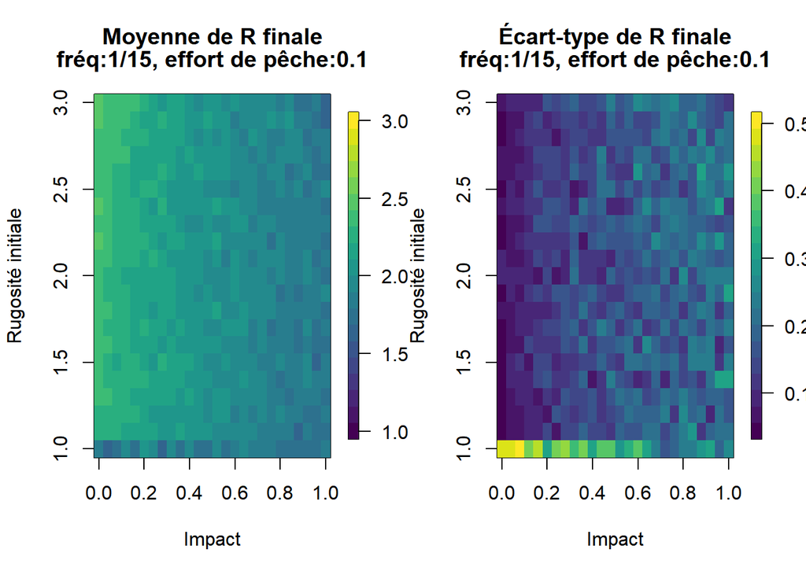

```r
#graphique de R finale en fonction de I et R
graph.imageRIR <- function(fishing,freq,it=10,pas=0.1){

  matC <- matrix(0, nrow = 21,ncol = 26)
  matsd <- matrix(0, nrow = 21,ncol = 26)

  f0<-fishing
  l<-freq
  for (i in 1:21) {
    for (j in 1:26){
      res <- vector(length = 0)
      for (z in 1:it) {
        R1 <- i*0.1+0.9
        imp <- j*0.04-0.04
        w <- corailstochastiquev2(R0=R1,f=f0, lambda = l,impact = imp,dt=pas, graph = F)[2]
        res<-c(res,w)
      }
      matC[i,j]<-mean(res)
      matsd[i,j]<-sd(res)
    }
  }

  x_values <- seq(0, 1, length.out = ncol(matC))
  y_values <- seq(1, 3, length.out = nrow(matC))
  # Plot the matrix as an image with different colored pixels

  par(mfrow=c(1,2))
  image.plot(x = x_values, y = y_values, t(matC), col = viridis(20), zlim=c(1,3),
             xlab = "Impact", ylab = "Rugosité initiale",
             main=c("Moyenne de R finale",paste(c("fréq:1/",1/l,", effort de pêche:",f0),collapse = "")))
  image.plot(x = x_values, y = y_values, t(matsd), col = viridis(20),
             xlab = "Impact", ylab = "Rugosité initiale",
             main=c("Écart-type de R finale",paste(c("fréq:1/",1/l,", effort de pêche:",f0),collapse = "")))
}
graph.imageRIR(fishing = 0.1, freq = 1/15, it=10, pas = 0.1)
```

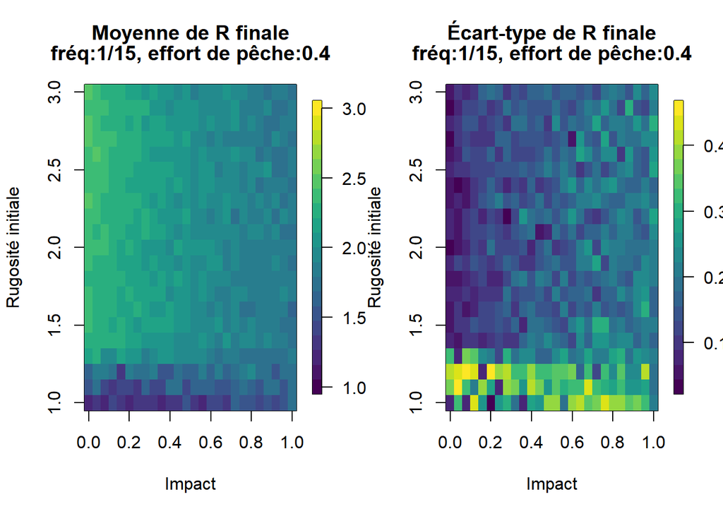

```r
graph.imageRIR(fishing = 0.4, freq = 1/15, it=10, pas = 0.1)
```

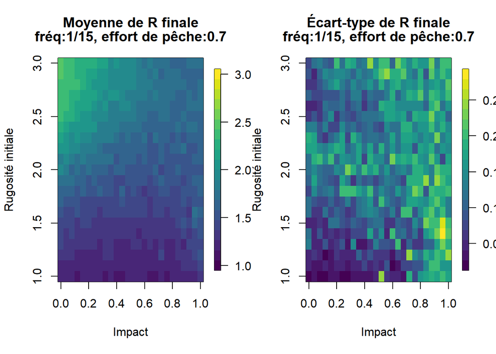

```r
graph.imageRIR(fishing = 0.7, freq = 1/15, it=10, pas = 0.1)
```

Un élément notable des graphiques présentant l’état de la rugosité est qu’ils ont tendance a s’équilibrer vers une rugosité de 2. De plus, la tendance d’une diminution selon l’impact des ouragans reste présente dans l’état de la rugosité comme dans l’état du corail.

## Discussion

Les récifs coralliens sont soumis à une variété de perturbations et de stress, parmi lesquelles il y a les ouragans. Ces phénomènes météorologiques violents constituent une menace pour la stabilité et la santé des écosystèmes coralliens. L’exploration du rôle des ouragans en tant que perturbation pour les récifs coralliens est nécessaire puisque les changements climatiques augmentent de plus en plus la force et l’impact des ouragans (Hernández-Delgado et al. (2024)).

Les analyses sur la corrélation entre la rugosité des récifs et l’impact des ouragans, selon trois niveaux d’effort de pêche pour l’état des coraux, ont révélé plusieurs éléments intéressants. Tout d’abord, il est possible de constater que plus l’impact des ouragans est élevé, plus les populations de coraux est instable. Cette observation est en accord avec notre modèle, car les impacts majeurs qui sont dans notre cas le maximum de dommage qu’un ouragan peut causer peuvent gravement perturber les écosystèmes coralliens, engendrant des déséquilibres importants. De plus, il est à noter que ces situations correspondent souvent à des ouragans survenant en fin de simulation. La gravité de l’impact prolonge le temps nécessaire à la récupération des coraux, laissant ainsi peu de temps pour un rétablissement complet avant la fin de la simulation.Toutefois, il est intéressant de noter que cette tendance est légère quand les efforts de pêche sont faibles ou moyens. L’impact des ouragans se fait véritablement ressentir lorsque l’effort de pêche est élevé. Dans ce cas, la diminution des populations de poissons-perroquets a un effet significatif sur la rugosité minimale nécessaire à la résilience des coraux. En effet, la compétition accrue avec les macroalgues, résultant de la diminution des poissons-perroquets, compromet la capacité des récifs à maintenir leur résilience. Par conséquent, lors d’ouragans de forte intensité, la rugosité des récifs est davantage affectée et a tendance à franchir le seuil critique de résilience des coraux.

Un deuxième élément intéressant est qu’avec un effort de pêche plus important, la rugosité minimale pour une résilience des coraux augmente. Ce phénomène est le même qu’entre l’abondance des populations perroquet et la rugosité des récifs coralliens minimal pour leur résilience, mais au lieu que la limite soit atteinte par une perturbation, elle est naturellement atteinte. Ainsi, avec effort de pêche moyen, une rugosité de 1.1 ou 1.2 n’est pas assez pour soutenir la persistance des récifs coralliens.

Un autre élément notable est que les trois simulations possèdent une large étendue d’écart-type, les écarts maximums allant jusqu’à 30% pour une même simulation. Une étendue large d’écart-type démontre une instabilité au niveau des populations avec les mêmes conditions de départ. Toutefois, il est possible d’attribuer cette divergence aux ouragans qui surviennent proche de la fin des simulations. Ainsi, dépendant quand l’ouragan survient et de la force de son impact, il y a beaucoup de scénarios possibles. Sinon, les autres zones d’instabilité sont des zones proches des limites de rugosité nécessaire pour la résilience de coraux. Ces zones peuvent avec un peu de chance être des situations favorable au corail ou défavorable avec moins de chance d’où l’instabilité.

Dans des recherches futures, il serait intéressant d’explorer d’autre stress qui pourrait avoir plus d’impact sur les dynamiques de population que les ouragans qui ont montré un effet notable seulement à des niveaux élevés de pêche.

## Référence

Blackwood, Julie C., Alan Hastings, and Peter J. Mumby. 2011. “A Model-Based Approach to Determine the Long-Term Effects of Multiple Interacting Stressors on Coral Reefs.” *Ecological Applications* 21 (7): 2722–33. https://doi.org/10.1890/10-2195.1.

Hernández-Delgado, Edwin A., Pedro Alejandro-Camis, Gerardo Cabrera-Beauchamp, Jaime S. Fonseca-Miranda, Nicolás X. Gómez-Andújar, Pedro Gómez, Roger Guzmán-Rodríguez, Iván Olivo-Maldonado, and Samuel E. Suleimán-Ramos. 2024. “Stronger Hurricanes and Climate Change in the Caribbean Sea: Threats to the Sustainability of Endangered Coral Species.” *Sustainability* 16 (4): 1506. https://doi.org/10.3390/su16041506.

Pérez-Cervantes, Esmeralda, Fernando Pardo Urrutia, Lorenzo Alvarez-Filip, Fernando Secaira Fajardo, Claudia Ruiz Alvarado, and Mariana Alvarez. 2020. “Coral Reefs Damages Caused by Hurricanes in the Caribbean and Their Correlation with the Characteristics of Hurricanes and Reefs.” https://doi.org/10.13140/RG.2.2.33420.18564.